# AVP Ticket Sales:Fall 2016, Spring 2017

Shade Wilson

8/9/2017

Example data frame (from fall 2016), extrapolated from data collected: date and time purchased, student or adult, which night, and payment method. Very easy to keep track of. So far we have (semi) detailed sales records for two semesters, and it’s important to continue with this trend so AVP can make the most informed decisions possible.

```
## # A tibble: 135 x 10
##     wday           date_time fri_stud sat_stud fri_deal fri_adult sat_adult method total profit
##    <ord>              <dttm>    <int>    <int>    <int>     <int>     <int>  <chr> <int>  <dbl>
##  1   Sun 2016-11-13 20:00:00        0        0        0         8         0 online     8     80
##  2   Sun 2016-11-13 23:55:00        0        0        0         0         5 online     5     50
##  3   Sun 2016-11-13 23:55:00        0        2        0         0         0 online     2     12
##  4   Sun 2016-11-13 23:55:00        1        0        0         1         0 online     2     16
##  5   Sun 2016-11-13 23:55:00        1        0        0         0         0 online     1      6
##  6   Mon 2016-11-14 11:01:00        0        0        3         0         0  venmo     3     12
##  7   Mon 2016-11-14 11:02:00        0        0        3         0         0  venmo     3     12
##  8   Mon 2016-11-14 11:36:00        0        1        0         0         0   cash     1      6
##  9   Mon 2016-11-14 11:46:00        1        0        3         0         0   card     4     18
## 10   Mon 2016-11-14 11:50:00        0        0        3         0         0  venmo     3     12
## # ... with 125 more rows
```

### Total Tickets Sold Per Night and Per Category

Despite a 3-for-2 deal on Friday in the fall, more tickets were sold in the spring overall, and the gross profit from the spring eclispes that of the fall. In the fall, 138 tickets were sold on Friday and 109 on Saturday for a total of 247 tickets overall. In the spring, sales reached 127 tickets on Friday and 153 on Saturday, bringing the total to 280 tickets sold.

Ticket sales in the fall grossed $1508 and $2210 in the spring. The costs per night in the fall were as follows: $500 for Jerry, $38 for awesome, $22 for security guard (one night). Additionally, were was a cost for printing programs, but the records have been lost. More likely, they never existed. In the spring, the costs were: $1100 for Jerry, $55 for awesome, and $150 for the security guard(s).

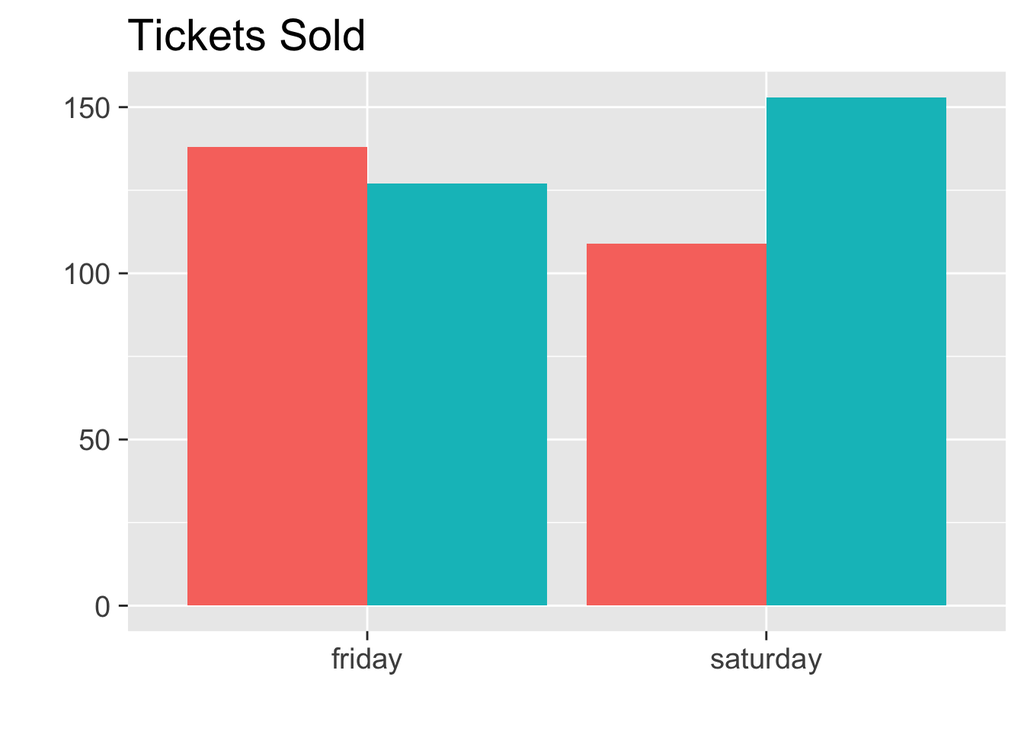

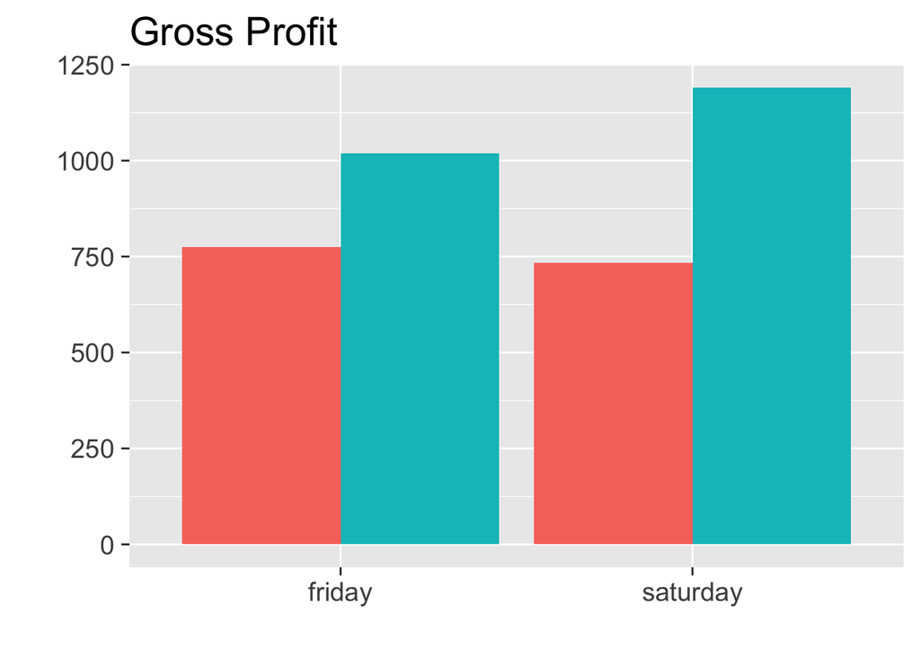

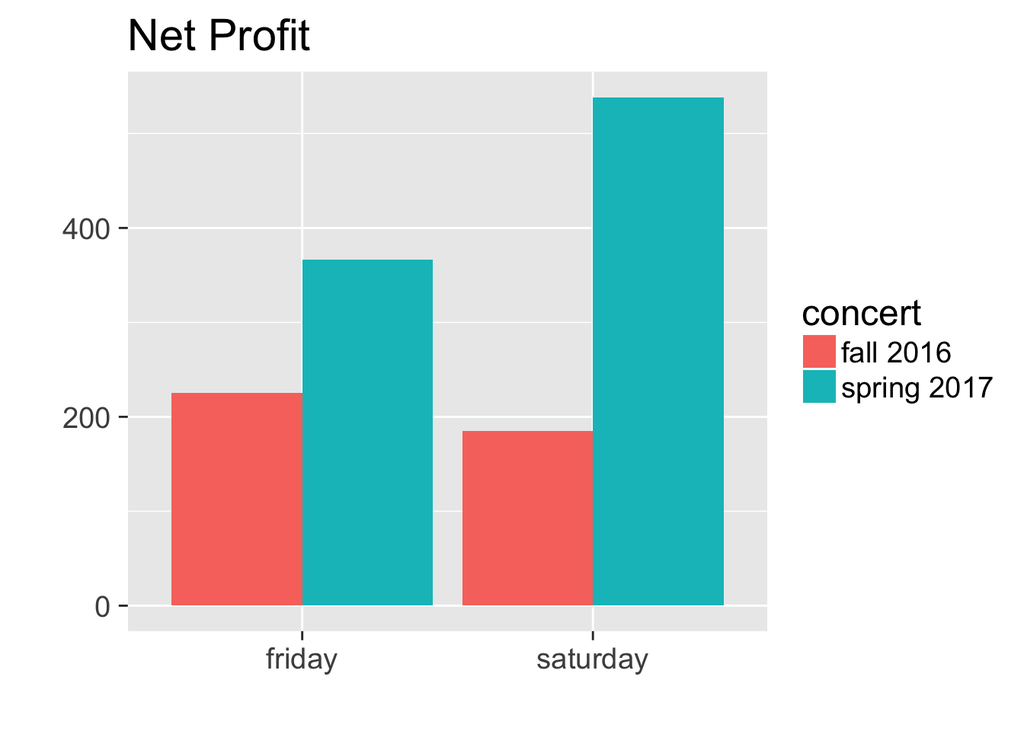

### Payment Methods

Around a third of total tickets for both semesters were sold at the door, so for the future, don’t lose hope if tabling and online sales aren’t exactly what you want. Door sales may be influenced by the weather and the amount of time into the semester: the better the weather and the earlier into the semester, the more likely people are to go to an a cappella concert on a whim.

[figure not shown]

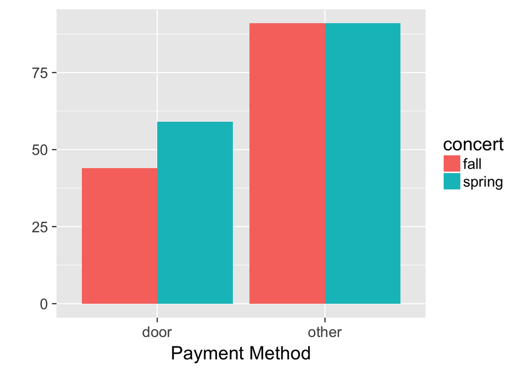

### Ticket Sales per Day

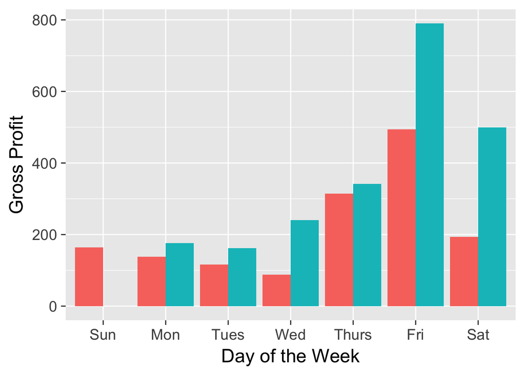

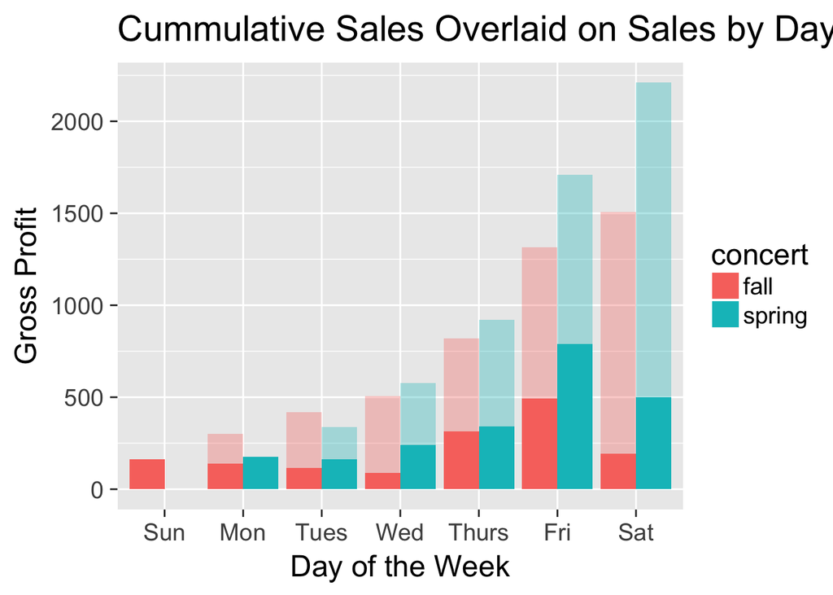

### Tabling Ticket Sales

Sales peak around noon (lunchtime). Expect sales to be particularly slow on Tuesdays. Ticket sales before 11 are few and far between. Due to the hecticness of the week resulting in lack of sleep, I personally don’t believe it’s worth harrassing AVP members out of bed early to sell tickets to one person. However, the table should certainly be up and running before 11 to catch those leaving their 10 AMs/9:30s. Consistency is the most important thing to keep in mind. Tabling is very weather dependent and success varies wildly, so the data presented here certainly cannot be considered definitive.

Overall, tickets sold at the table are almost negligible, but the advertising is not. Keep it in mind that the most important part of tabling is getting word of the concert out. The only people that really buy tickets at the table are those that know a lot about AVP and are sure they’re coming before the week even begins (friends and that one groupie) and those that buy a ticket on a whim (very few in my experience). I would recommend printing advert fliers to hand out to the overwhelming majority of students who have no idea about the group or are on the fence.

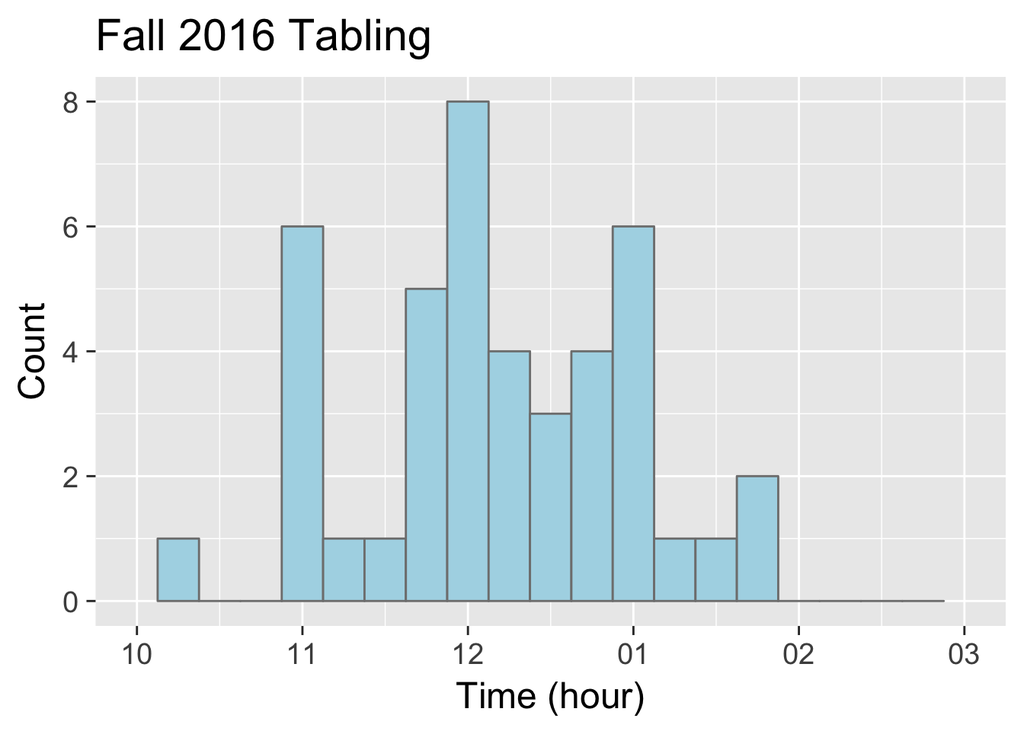

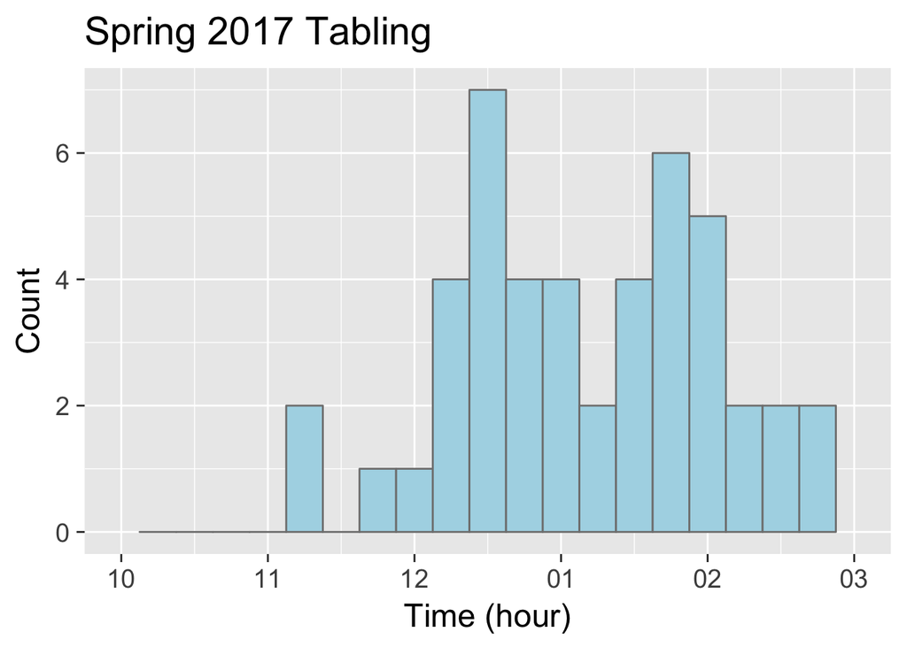

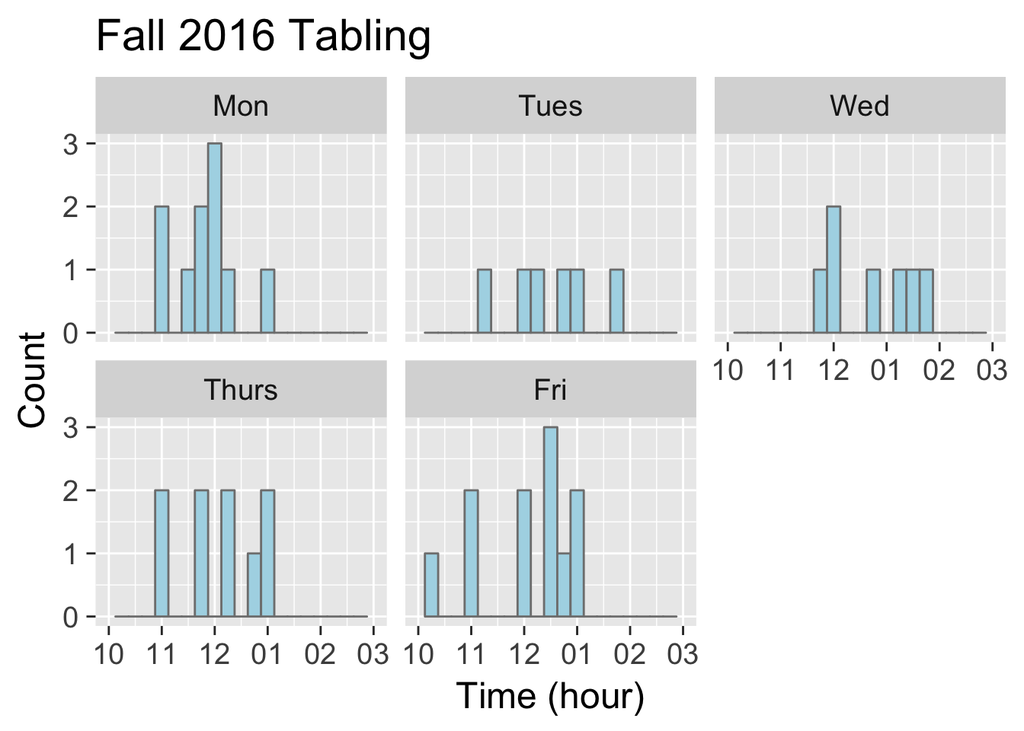

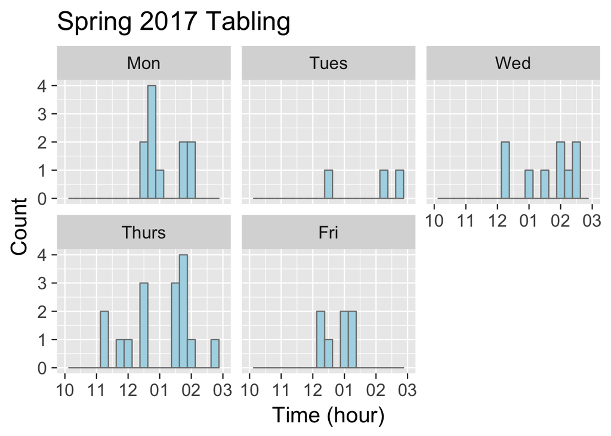